# Coder Upgrade 2023: Seurat Under the Hood

Matt Cannon

04/11/2023

Load libraries

```r
library(rrrSingleCellUtils)
library(tidyverse)
library(Seurat)
```

# Section 1: Objects in R and Seurat objects

R has many variable types

```r
my_vector <- c(1, 2, 3, 4, 5)
my_matrix <- matrix(1:9, nrow = 3)
my_data_frame <- data.frame(x = 1:5, y = 6:10)
my_list <- list(a = 1, b = 2, c = "stuff")
```

R is mostly a “functional language”

But it also has some “object oriented” features

- Objects are a way to store data and functions together
- Objects are intended to be “black boxes” that you can interact with
- Methods or functions are used to interact with objects
- Conceptually different than normal variables
  - Variables are meant to be directly manipulated
  - Objects are meant to be interacted with through methods

- S3
  - The original object type in R
  - Less strictly defined
- S4
  - More strictly defined
  - More complicated to create
  - Less prone to errors
- R6
  - More traditional OO behavior
  - Not super common

## Seurat objects are S4 objects

```r
isS4(pbmc_small)
```

```
## [1] TRUE
```

```r
class(pbmc_small)
```

```
## [1] "Seurat"
## attr(,"package")
## [1] "SeuratObject"
```

This is the code that defines a Seurat object

```r
Seurat <- setClass(
  Class = 'Seurat',
  slots = c(
    assays = 'list',
    meta.data = 'data.frame',
    active.assay = 'character',
    active.ident = 'factor',
    graphs = 'list',
    neighbors = 'list',
    reductions = 'list',
    images = 'list',
    project.name = 'character',
    misc = 'list',
    version = 'package_version',
    commands = 'list',
    tools = 'list'
  )
)
```

Then methods/functions are created to work with Seurat objects

Note that the function has a function name (merge), then “.”, then the object type (Seurat)

This tells R how to use the merge function on a Seurat object

```r
merge.Seurat <- function(
  x = NULL,
  y = NULL,
  add.cell.ids = NULL,
  merge.data = TRUE,
  merge.dr = NULL,
  project = "SeuratProject",
  ...
) {
  CheckDots(...)
  objects <- c(x, y)
  if (!is.null(x = add.cell.ids)) {
    if (length(x = add.cell.ids) != length(x = objects)) {
      stop("Please provide a cell identifier for each object provided to merge")
    }
    for (i in 1:length(x = objects)) {
      objects[[i]] <- RenameCells(object = objects[[i]], add.cell.id = add.cell.ids[i])
    }
  }
  # ensure unique cell names
  objects <- CheckDuplicateCellNames(object.list = objects)
  assays <- lapply(
    X = objects,
    FUN = FilterObjects,
    classes.keep = 'Assay'
  )
#
#more stuff down here, but you get the idea
#
}
```

## Why do it this way?

- The structure of an object is defined and static
- Can write functions that are “guaranteed” to work with objects of a certain type
- Can exend base R functions to work with objects of a certain type

```r
str(pbmc_small)
```

> Show ppt slide with Seurat object structure

## Seurat object slots:

There are only a handful of slots in a Seurat object

But, each slot can contain objects, which then have their own slots

Ends up looking really complex if you don’t break it down by level

- assays = ‘list’
  - list of assay objects containing the gene expression data
- meta.data = ‘data.frame’
  - Metadata for each cell
- active.assay = ‘character’
  - Which assay is currently active
- active.ident = ‘factor’
  - Vector of default “idents” for each cell
- graphs = ‘list’
  - Filled in by `FindNeighbors()`
- neighbors = ‘list’
  - Filled in by `FindNeighbors()`
- reductions = ‘list’
  - Dimensionality reduction results
- images = ‘list’
  - Not really applicable to our type of data
- project.name = ‘character’
  - Name of the project
- misc = ‘list’
- version = ‘package_version’
- commands = ‘list’
  - **List of commands used to create the object**
- tools = ‘list’

# Activity 1:

Explore the pbmc_small Seurat object

Type “pbmc_small@” in the console/terminal, then hit tab a few times to see the available slots

Type “pbmc_small$” in the console/terminal, then hit tab a few times to see the metadata column names

What commands were used to create the object? What resolution was used in `FindClusters()`?

What are the active assay and active identity of this object?

Pull the metadata out of the object and save it as a new variable

What data are in the rownames of the metadata?

# Section 2: Assay object structure

The “@assay” slot of a Seurat object contains the actual gene expression data

Each element of the list is an assay object

> Show ppt of Assay object structure

## Assay object slots:

- counts = ‘matrix’ - usually a sparse matrix (dgCMatrix)
  - Raw counts
- data = ‘matrix’ - usually a sparse matrix (dgCMatrix)
  - Normalized counts
- scale.data = ‘matrix’
  - Scaled counts
- key = ‘character’
  - Not used externally
- assay.orig = ‘character’
  - Label for the assay
- var.features = ‘vector’
  - Vector of variable genes
- meta.features = ‘data.frame’
- misc = ‘list’

```r
class(pbmc_small@assays[[1]])
```

## Navigating a Seurat object

Key concepts:

- Start with object name
- Use “@” to access the slot you want
- If the slot contains a list, reference it by name
- If you are referencing an internal object, use “@” to access the slot you want
- Repeat all the way down to the bit you need

> Show ppt of navigating Seurat object

```
obj            slot            list element     slot of "DimReduc" object
pbmc_small     @reductions     $pca             @cell.embeddings
```

```r
pca_stuff <- pbmc_small@reductions$pca@cell.embeddings
pca_stuff[1:10, 1:3]
```

```
##                       PC_1       PC_2       PC_3
## ATGCCAGAACGACT -0.77403708 -0.8996461 -0.2493078
## CATGGCCTGTGCAT -0.02602702 -0.3466795  0.6651668
## GAACCTGATGAACC -0.45650250  0.1795811  1.3175907
## TGACTGGATTCTCA -0.81163243 -1.3795340 -1.0019320
## AGTCAGACTGCACA -0.77403708 -0.8996461 -0.2493078
## TCTGATACACGTGT -0.77403708 -0.8996461 -0.2493078
## TGGTATCTAAACAG -0.46034009 -1.1872843 -0.3117314
## GCAGCTCTGTTTCT -0.90033933 -0.3880251  0.6931944
## GATATAACACGCAT -0.77403708 -0.8996461 -0.2493078
## AATGTTGACAGTCA -0.48779823 -1.1621071 -0.3062674
```

## Fun with @commands

This list is structured to make pulling out specific commands easier

- Each element of the list is named by the specific command run
- This in turn is a named list of arguments

```r
pbmc_small@commands$FindVariableFeatures.RNA$nfeatures
```

```
## [1] 20
```

```
obj          slot       command                     argument
pbmc_small   @commands  $FindVariableFeatures.RNA   $nfeatures
```

## Other random manual bits

Getting cell names and gene names

```r
genes <- rownames(pbmc_small)
head(genes)
```

```
## [1] "MS4A1"    "CD79B"    "CD79A"    "HLA-DRA"  "TCL1A"    "HLA-DQB1"
```

```r
cells <- colnames(pbmc_small)
head(cells)
```

```
## [1] "ATGCCAGAACGACT" "CATGGCCTGTGCAT" "GAACCTGATGAACC" "TGACTGGATTCTCA"
## [5] "AGTCAGACTGCACA" "TCTGATACACGTGT"
```

Subsetting a Seurat object by row/column numbers

```
        genes        cells
```

object_name[row_numbers, column_numbers]

```r
subset_data <- pbmc_small[1:50, 1:20]
subset_data
```

```
## An object of class Seurat
## 50 features across 20 samples within 1 assay
## Active assay: RNA (50 features, 1 variable features)
##  2 dimensional reductions calculated: pca, tsne
```

# Activity 2:

Pull the “RNA” assay out of the Seurat object and save it as a new variable named `rna_assay`

Pull the raw counts out of `rna_assay`, save it as a new variable named “rna_counts” and look at the first 6 rows

# Section 3: Interacting with Seurat objects

## The “right way”

Use Seurat functions to interact with the object instead of diving into the object

Key functions

## Set active Idents

```r
Idents(pbmc_small) <- "letter.idents"
table(Idents(pbmc_small))
```

```
##
##  A  B
## 53 27
```

```r
Idents(pbmc_small) <- "this_is_not_a_real_column_in_the_data"
table(Idents(pbmc_small))
```

```
##
## this_is_not_a_real_column_in_the_data
##                                    80
```

```r
Idents(pbmc_small) <- pbmc_small$letter.idents
table(Idents(pbmc_small))
```

```
##
##  A  B
## 53 27
```

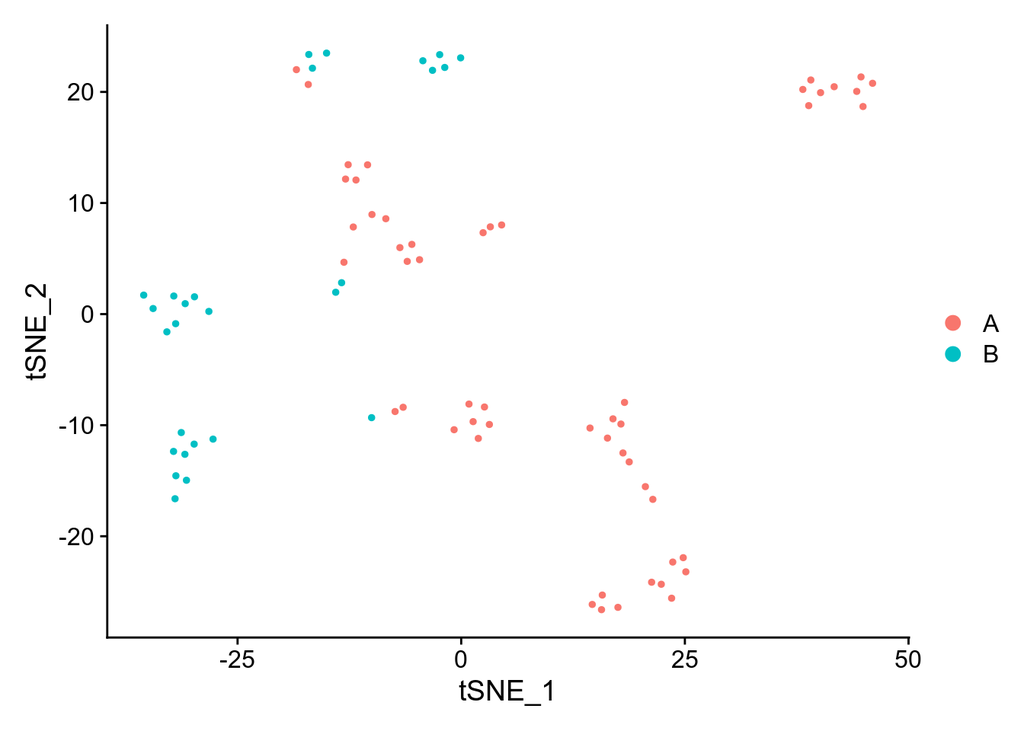

```r
DimPlot(pbmc_small)
```

## Get list of cells

```r
cells <- Cells(pbmc_small)
```

## Get expression data

- counts - raw counts
- data - normalized counts *<- you most likely want this*
- scale.data - scaled counts

Returns sparse matrix

```r
my_data <- GetAssayData(pbmc_small, assay = "RNA", slot = "counts")

GetAssayData(pbmc_small, slot = "counts")[1:5, 1:5] %>%
    as.matrix()
```

```
##         ATGCCAGAACGACT CATGGCCTGTGCAT GAACCTGATGAACC TGACTGGATTCTCA
## MS4A1                0              0              0              0
## CD79B                1              0              0              0
## CD79A                0              0              0              0
## HLA-DRA              0              1              0              0
## TCL1A                0              0              0              0
##         AGTCAGACTGCACA
## MS4A1                0
## CD79B                0
## CD79A                0
## HLA-DRA              1
## TCL1A                0
```

```r
GetAssayData(pbmc_small, slot = "data")[1:5, 1:5] %>%
    as.matrix()
```

```
##         ATGCCAGAACGACT CATGGCCTGTGCAT GAACCTGATGAACC TGACTGGATTCTCA
## MS4A1         0.000000       0.000000              0              0
## CD79B         4.968821       0.000000              0              0
## CD79A         0.000000       0.000000              0              0
## HLA-DRA       0.000000       4.776153              0              0
## TCL1A         0.000000       0.000000              0              0
##         AGTCAGACTGCACA
## MS4A1         0.000000
## CD79B         0.000000
## CD79A         0.000000
## HLA-DRA       4.074201
## TCL1A         0.000000
```

```r
GetAssayData(pbmc_small, slot = "scale.data")[1:5, 1:5] %>%
    as.matrix()
```

```
##          ATGCCAGAACGACT CATGGCCTGTGCAT GAACCTGATGAACC TGACTGGATTCTCA
## IGLL5        -0.1934952     -0.1934952     -0.1934952     -0.1934952
## S100A8       -0.7048050     -0.7048050     -0.7048050     -0.7048050
## S100A9       -0.7639656      0.9016133      0.8935721     -0.7639656
## HLA-DPB1     -1.0399941     -1.0399941     -1.0399941     -1.0399941
## HLA-DQA1     -0.6717070     -0.6717070     -0.6717070      1.2439601
##          AGTCAGACTGCACA
## IGLL5        -0.1934952
## S100A8       -0.7048050
## S100A9       -0.7639656
## HLA-DPB1     -1.0399941
## HLA-DQA1     -0.6717070
```

## Drop new data into an object

```r
raw_counts <-
    GetAssayData(pbmc_small, slot = "counts") %>%
    as.matrix()

bad_normalization <- raw_counts / colSums(raw_counts)
pbmc_small_borked <-
    SetAssayData(pbmc_small,
                 slot = "data",
                 new.data = bad_normalization)
```

## Subset a Seurat object

```r
# Note that there is only one equal sign here
just_a <- subset(pbmc_small, idents = "A")

# But two equal signs here
just_a <- subset(pbmc_small, letter.idents == "A")

a_cells <- WhichCells(pbmc_small, idents = "A")

just_a <- subset(pbmc_small, cells = a_cells)
```

## Calculate average expression per group

```r
ave_expr <- AverageExpression(pbmc_small, group.by = "letter.idents")$RNA
ave_expr[1:5, ]
```

```
##                 A          B
## MS4A1    61.52243   1.929114
## CD79B    61.21571  17.561843
## CD79A    77.10662  10.757716
## HLA-DRA 417.74630 420.190327
## TCL1A    50.93247   3.206670
```

## Add metadata

If adding a dataframe of metadata, need rownames of cell names When adding with “$”, or passing a vector to `AddMetaData`, it doesn’t check if cells match

```r
pbmc_small$nonsense <- sample(LETTERS[1:5],
                              ncol(pbmc_small),
                              replace = TRUE)

metadata_table <-
    data.frame(totally_true = sample(c("alive", "dead", "undead"),
                                     ncol(pbmc_small),
                                     replace = TRUE),
               also_useful = sample(1:1000000,
                                    ncol(pbmc_small),
                                    replace = FALSE),
               row.names = colnames(pbmc_small))

pbmc_small_plus <- AddMetaData(pbmc_small, metadata_table)
head(pbmc_small_plus@meta.data)
```

```
##                   orig.ident nCount_RNA nFeature_RNA RNA_snn_res.0.8
## ATGCCAGAACGACT SeuratProject         70           47               0
## CATGGCCTGTGCAT SeuratProject         85           52               0
## GAACCTGATGAACC SeuratProject         87           50               1
## TGACTGGATTCTCA SeuratProject        127           56               0
## AGTCAGACTGCACA SeuratProject        173           53               0
## TCTGATACACGTGT SeuratProject         70           48               0
##                letter.idents groups RNA_snn_res.1 nonsense totally_true
## ATGCCAGAACGACT             A     g2             0        A         dead
## CATGGCCTGTGCAT             A     g1             0        D       undead
## GAACCTGATGAACC             B     g2             0        A         dead
## TGACTGGATTCTCA             A     g2             0        B        alive
## AGTCAGACTGCACA             A     g2             0        E         dead
## TCTGATACACGTGT             A     g1             0        C        alive
##                also_useful
## ATGCCAGAACGACT      880124
## CATGGCCTGTGCAT      347764
## GAACCTGATGAACC       92737
## TGACTGGATTCTCA      488905
## AGTCAGACTGCACA      377617
## TCTGATACACGTGT      227455
```

```r
pbmc_small_plus <- AddMetaData(pbmc_small_plus,
                               colnames(pbmc_small_plus),
                               col.name = "cell_ids")
head(pbmc_small_plus@meta.data)
```

```
##                   orig.ident nCount_RNA nFeature_RNA RNA_snn_res.0.8
## ATGCCAGAACGACT SeuratProject         70           47               0
## CATGGCCTGTGCAT SeuratProject         85           52               0
## GAACCTGATGAACC SeuratProject         87           50               1
## TGACTGGATTCTCA SeuratProject        127           56               0
## AGTCAGACTGCACA SeuratProject        173           53               0
## TCTGATACACGTGT SeuratProject         70           48               0
##                letter.idents groups RNA_snn_res.1 nonsense totally_true
## ATGCCAGAACGACT             A     g2             0        A         dead
## CATGGCCTGTGCAT             A     g1             0        D       undead
## GAACCTGATGAACC             B     g2             0        A         dead
## TGACTGGATTCTCA             A     g2             0        B        alive
## AGTCAGACTGCACA             A     g2             0        E         dead
## TCTGATACACGTGT             A     g1             0        C        alive
##                also_useful       cell_ids
## ATGCCAGAACGACT      880124 ATGCCAGAACGACT
## CATGGCCTGTGCAT      347764 CATGGCCTGTGCAT
## GAACCTGATGAACC       92737 GAACCTGATGAACC
## TGACTGGATTCTCA      488905 TGACTGGATTCTCA
## AGTCAGACTGCACA      377617 AGTCAGACTGCACA
## TCTGATACACGTGT      227455 TCTGATACACGTGT
```

## Get PCA/UMAP/TSNE values

```r
tsne_data <- Embeddings(pbmc_small, reduction = "tsne")

pca_data <- Embeddings(pbmc_small, reduction = "pca")
```

## Get cell names for specific cells

```r
high_cd79b <- WhichCells(pbmc_small, expression = CD79B > 2)
head(high_cd79b)
```

```
## [1] "ATGCCAGAACGACT" "AATGTTGACAGTCA" "AGGTCATGAGTGTC" "AGAGATGATCTCGC"
## [5] "GGGTAACTCTAGTG" "CATGAGACACGGGA"
```

```r
group_b <- WhichCells(pbmc_small, idents = "B")
length(group_b)
```

```
## [1] 27
```

## Get data for specific cells

```r
high_cd79b_data <-
    FetchData(pbmc_small, vars = rownames(pbmc_small), cells = high_cd79b)

high_cd79b_data[1:5, 1:5]
```

```
##                   MS4A1    CD79B    CD79A  HLA-DRA    TCL1A
## ATGCCAGAACGACT 0.000000 4.968821 0.000000 0.000000 0.000000
## AATGTTGACAGTCA 0.000000 4.615121 0.000000 0.000000 0.000000
## AGGTCATGAGTGTC 5.779448 5.779448 0.000000 7.722706 6.183883
## AGAGATGATCTCGC 4.660719 5.349125 5.571318 7.290953 0.000000
## GGGTAACTCTAGTG 5.984036 5.697193 5.293404 7.486153 5.293404
```

```r
high_cd79b_data <-
    FetchData(pbmc_small,
              vars = c("groups", "letter.idents", "nonsense"),
              cells = high_cd79b)

head(high_cd79b_data)
```

```
##                groups letter.idents nonsense
## ATGCCAGAACGACT     g2             A        A
## AATGTTGACAGTCA     g1             A        A
## AGGTCATGAGTGTC     g2             A        E
## AGAGATGATCTCGC     g1             A        E
## GGGTAACTCTAGTG     g2             A        B
## CATGAGACACGGGA     g2             A        B
```

## Save your Idents

```r
pbmc_small <- StashIdent(pbmc_small, "my_idents")
```

```
## With Seurat 3.X, stashing identity classes can be accomplished with the following:
## pbmc_small[["my_idents"]] <- Idents(object = pbmc_small)
```

```r
head(pbmc_small$my_idents)
```

```
## ATGCCAGAACGACT CATGGCCTGTGCAT GAACCTGATGAACC TGACTGGATTCTCA AGTCAGACTGCACA
##              A              A              B              A              A
## TCTGATACACGTGT
##              A
## Levels: A B
```

# Wrapup

A Seurat object in an S4 object

Functions similar to a list of lists, except that the slots are accessed with “@” instead of “$”

The authors of the software wrote a lot of functions to interact with the object, so you don’t have to dive into the object manually

But, if you need to, you can!

This should make a lot more sense now!

```r
str(pbmc_small)
```

```
## Formal class 'Seurat' [package "SeuratObject"] with 13 slots
##   ..@ assays      :List of 1
##   .. ..$ RNA:Formal class 'Assay' [package "SeuratObject"] with 8 slots
##   .. .. .. ..@ counts       :Formal class 'dgCMatrix' [package "Matrix"] with 6 slots
##   .. .. .. .. .. ..@ i       : int [1:4456] 1 5 8 11 22 30 33 34 36 38 ...
##   .. .. .. .. .. ..@ p       : int [1:81] 0 47 99 149 205 258 306 342 387 423 ...
##   .. .. .. .. .. ..@ Dim     : int [1:2] 230 80
##   .. .. .. .. .. ..@ Dimnames:List of 2
##   .. .. .. .. .. .. ..$ : chr [1:230] "MS4A1" "CD79B" "CD79A" "HLA-DRA" ...
##   .. .. .. .. .. .. ..$ : chr [1:80] "ATGCCAGAACGACT" "CATGGCCTGTGCAT" "GAACCTGATGAACC" "TGACTGGATTCTCA" ...
##   .. .. .. .. .. ..@ x       : num [1:4456] 1 1 3 1 1 4 1 5 1 1 ...
##   .. .. .. .. .. ..@ factors : list()
##   .. .. .. ..@ data         :Formal class 'dgCMatrix' [package "Matrix"] with 6 slots
##   .. .. .. .. .. ..@ i       : int [1:4456] 1 5 8 11 22 30 33 34 36 38 ...
##   .. .. .. .. .. ..@ p       : int [1:81] 0 47 99 149 205 258 306 342 387 423 ...
##   .. .. .. .. .. ..@ Dim     : int [1:2] 230 80
##   .. .. .. .. .. ..@ Dimnames:List of 2
##   .. .. .. .. .. .. ..$ : chr [1:230] "MS4A1" "CD79B" "CD79A" "HLA-DRA" ...
##   .. .. .. .. .. .. ..$ : chr [1:80] "ATGCCAGAACGACT" "CATGGCCTGTGCAT" "GAACCTGATGAACC" "TGACTGGATTCTCA" ...
##   .. .. .. .. .. ..@ x       : num [1:4456] 4.97 4.97 6.06 4.97 4.97 ...
##   .. .. .. .. .. ..@ factors : list()
##   .. .. .. ..@ scale.data   : num [1:20, 1:80] -0.193 -0.705 -0.764 -1.04 -0.672 ...
##   .. .. .. .. ..- attr(*, "dimnames")=List of 2
##   .. .. .. .. .. ..$ : chr [1:20] "IGLL5" "S100A8" "S100A9" "HLA-DPB1" ...
##   .. .. .. .. .. ..$ : chr [1:80] "ATGCCAGAACGACT" "CATGGCCTGTGCAT" "GAACCTGATGAACC" "TGACTGGATTCTCA" ...
##   .. .. .. ..@ key          : chr "rna_"
##   .. .. .. ..@ assay.orig   : NULL
##   .. .. .. ..@ var.features : chr [1:20] "PPBP" "IGLL5" "VDAC3" "CD1C" ...
##   .. .. .. ..@ meta.features:'data.frame':   230 obs. of  5 variables:
##   .. .. .. .. ..$ vst.mean                 : num [1:230] 0.388 0.6 0.7 13.425 0.3 ...
##   .. .. .. .. ..$ vst.variance             : num [1:230] 1.025 1.281 4.365 725.463 0.871 ...
##   .. .. .. .. ..$ vst.variance.expected    : num [1:230] 1.141 2.708 4.018 745.526 0.642 ...
##   .. .. .. .. ..$ vst.variance.standardized: num [1:230] 0.898 0.473 1.086 0.973 1.356 ...
##   .. .. .. .. ..$ vst.variable             : logi [1:230] FALSE FALSE FALSE FALSE FALSE FALSE ...
##   .. .. .. ..@ misc         : NULL
##   ..@ meta.data   :'data.frame': 80 obs. of  9 variables:
##   .. ..$ orig.ident     : Factor w/ 1 level "SeuratProject": 1 1 1 1 1 1 1 1 1 1 ...
##   .. ..$ nCount_RNA     : num [1:80] 70 85 87 127 173 70 64 72 52 100 ...
##   .. ..$ nFeature_RNA   : int [1:80] 47 52 50 56 53 48 36 45 36 41 ...
##   .. ..$ RNA_snn_res.0.8: Factor w/ 2 levels "0","1": 1 1 2 1 1 1 1 1 1 1 ...
```

[output cut: 199 more lines]

```
##   .. .. .. ..@ time.stamp : POSIXct[1:1], format: "2019-05-02 18:26:26"
##   .. .. .. ..@ assay.used : chr "RNA"
##   .. .. .. ..@ call.string: chr [1:4] "FindVariableFeatures(object = pbmc_small, assay = \"RNA\", " "    selection.method = \"vst\", loess.span = 0.3, clip.max = \"auto\", " "    num.bin = 20, binning.method = \"equal_width\", nfeatures = 20, " "    mean.cutoff = c(0.1, 8), dispersion.cutoff = c(…
##   .. .. .. ..@ params     :List of 10
##   .. .. .. .. ..$ assay            : chr "RNA"
##   .. .. .. .. ..$ selection.method : chr "vst"
##   .. .. .. .. ..$ loess.span       : num 0.3
##   .. .. .. .. ..$ clip.max         : chr "auto"
##   .. .. .. .. ..$ num.bin          : num 20
##   .. .. .. .. ..$ binning.method   : chr "equal_width"
##   .. .. .. .. ..$ nfeatures        : num 20
##   .. .. .. .. ..$ mean.cutoff      : num [1:2] 0.1 8
##   .. .. .. .. ..$ dispersion.cutoff: num [1:2] 1 Inf
##   .. .. .. .. ..$ verbose          : logi TRUE
##   ..@ tools       : list()
```

# Activity 3:

# Helpful references

https://github.com/mojaveazure/seurat-object https://github.com/satijalab/seurat https://satijalab.org/seurat/reference/index.html https://satijalab.org/seurat/index.html